# What is the True Normal Human Body Temperature?

#### Background

The mean normal body temperature was held to be 37$^{\circ}$C or 98.6$^{\circ}$F for more than 120 years since it was first conceptualized and reported by Carl Wunderlich in a famous 1868 book. But, is this value statistically correct?

### Exercises

In this exercise, you will analyze a dataset of human body temperatures and employ the concepts of hypothesis testing, confidence intervals, and statistical significance.

Answer the following questions **in this notebook below and submit to your Github account**.

1. Is the distribution of body temperatures normal?
   - Although this is not a requirement for CLT to hold (read CLT carefully), it gives us some peace of mind that the population may also be normally distributed if we assume that this sample is representative of the population.
2. Is the sample size large? Are the observations independent?
   - Remember that this is a condition for the CLT, and hence the statistical tests we are using, to apply.
3. Is the true population mean really 98.6 degrees F?
   - Would you use a one-sample or two-sample test? Why?
   - In this situation, is it appropriate to use the $t$ or $z$ statistic?
   - Now try using the other test. How is the result be different? Why?
4. At what temperature should we consider someone's temperature to be "abnormal"?
   - Start by computing the margin of error and confidence interval.
5. Is there a significant difference between males and females in normal temperature?
   - What test did you use and why?
   - Write a story with your conclusion in the context of the original problem.

You can include written notes in notebook cells using Markdown: - In the control panel at the top, choose Cell > Cell Type > Markdown - Markdown syntax: http://nestacms.com/docs/creating-content/markdown-cheat-sheet #### Resources + Information and data sources: http://www.amstat.org/publications/jse/datasets/normtemp.txt, http://www.amstat.org/publications/jse/jse_data_archive.htm + Markdown syntax: http://nestacms.com/docs/creating-content/markdown-cheat-sheet ****

```python
import pandas as pd

df = pd.read_csv('data/human_body_temperature.csv')
```

```python
import numpy as np
import matplotlib.pyplot as plt
import matplotlib.mlab as mlab
from scipy.stats import norm
import scipy.stats
import math
```

```python
# Your work here.
df.head()
```

|  | temperature | gender | heart_rate |
| --- | --- | --- | --- |
| 0 | 99.3 | F | 68.0 |
| 1 | 98.4 | F | 81.0 |
| 2 | 97.8 | M | 73.0 |
| 3 | 99.2 | F | 66.0 |
| 4 | 98.0 | F | 73.0 |

```python
len(df)
```

```
130
```

```python
df.temperature.describe()
```

```
count    130.000000
mean      98.249231
std        0.733183
min       96.300000
25%       97.800000
50%       98.300000
75%       98.700000
max      100.800000
Name: temperature, dtype: float64
```

**Question 1: Is the distribution of body temperatures normal?**

Let's construct a histogram and visually check if the distribution follows a Normal curve

```python
temp_obs = df.temperature.sort_values()
```

```python
bin_values = np.arange(start=temp_obs.min(), stop=temp_obs.max(), step=.05)
```

```python
mu, std = temp_obs.mean(),temp_obs.std()
```

```python
p=norm.pdf(temp_obs,mu,std)
```

```python
plt.xlabel('Temperature')
#xticks = np.arange(96.0,101.0,0.1)
xticks = plt.xticks(np.arange(95.75,101.25,0.25),rotation=90)
plt.title(('Distribution of Temperature \nMean:'+('{:3.6}'.format(str(mu)))+
           ' *** Std. Dev:'+('{:1.6}'.format(str(std)))+
          ' *** Mode:'+('{:3.6}'.format(str(temp_obs.mode().values[0])))))
```

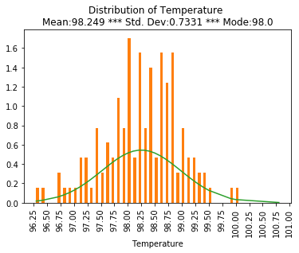

```python
n,bins,patches= plt.hist(temp_obs,bins=bin_values,normed=True,stacked=True)
plt.plot(temp_obs, p)
plt.show()
```

Now, let us check if the observations follow a Normal distribution using `normaltest` from `scipy.stats` </p>

```python
k2,p=scipy.stats.normaltest(temp_obs)
```

```python
print(m)#0.258747986349
```

[output not shown]

*As you can see from above `p` value, the observations do follow a Normal distribution*

**Question 2: Is the sample size large? Are the observations independent?**

```python
len(df)#130
```

```
130
```

```python
df[df.temperature.isnull()]
```

|  | temperature | gender | heart_rate |
| --- | --- | --- | --- |

As you can see from the above results, there are **130 observations** in the given dataset. It is generally accepted that if a sample has more than 30 observations, the sample is large. So in this case, *the sample size is large*

Each random variable in this sample and population measures the temperature of a human and *are independent observations*

**Question 3 a: Is the true population mean really 98.6 degrees F?**

- Would you use a one-sample or two-sample test? Why?

The objective of this exercise is to compare the mean of the given sample with the generally accepted human body temperature of 98.6 degrees. We *have to use a one-sample test* because we compare if a value falls within the possible values of a given population parameters. This is not a case where we intervene in a group and check if the group characteristics have changed due to the intervention, if this were the case, we would have used a two-sample test.

**Question 3 b:**

- In this situation, is it appropriate to use the $t$ or $z$ statistic? </ul> </font>

To check if the true population mean(**μ**) is really 98.6 degrees F, we have to compare if the sample mean (**x̄**) lies within statistically insignficant range of population mean. The hypothesis test is

H<sub>o</sub> : Population mean(**μ**) = Sample mean (**x̄**)

H<sub>a</sub> : Population mean(**μ**) ≠ Sample mean (**x̄**)

In this case

- the sample observations follow a Normal distribution
- the sample size **n** is large
- we do not know the population standard deviation(**σ**) .

so, *we will use a $t$ statistic*

The $t$ statistic is calculated as $t$ = (x̄ - μ) / (S /√n).

The two-tailed critical $t$ value for a 95% CI and 129 degrees of freedom is approx. **1.980**

Below is a $t$ table

[figure not shown]

```python
(temp_obs.mean()-98.6) / (temp_obs.std()/math.sqrt(130))#-5.454823292364301
```

```
-5.454823292364301
```

```python
#Calculate the t statistic using ttest_1samp from scipy.stats
scipy.stats.ttest_1samp(temp_obs,98.6)
```

```
Ttest_1sampResult(statistic=-5.4548232923640771, pvalue=2.4106320415610081e-07)
```

From the above we see that the $t$ value calclated (**-5.455**) for this sample is beyond the critical $t$ value of -1.980. The $p$ value of this is `2.4106320415610081e-07`